# Results from test models

Sarah Gaichas

2024-07-09

# Background

These are all exploratory test models. I’ve done no model selection. There are no covariates included yet.

Each is a univariate model. I’ve looked at *Calanus finmarchicus* (calfin), total Euphausiids (euph), total Hyperiids (hyper), and total zooplankton volume (zoopvolume).

All models but zoopvolume are estimating spatial and spatio-temporal random effects and anisotropy parameters for both the first and second linear predictors, set `purpose = "index2"` with the default `ObsModel = c(2,1)` meaning a Poisson-link function, and all but zoopvolume FALL appeared to converge. This setup was universally chosen based on model selection for other VAST models I’ve run, but I still need to do model selection to see if it makes sense for the zooplankton data.

Zoopvolume models could not be fit with the default link function because zoopvolume is measured at all stations, so the model can’t estimate encounter probability at 1 in the first linear predictor, we need to fix it at 1. Reading the code and documentation, I *think* I use `ObsModel = c(2,4)`, which should be Poisson-link function similar to the default used for other models, but fixing encounter probability=1 for any year where all samples encounter the species.

Zoopvolume models were initially estimating spatial or spatio-temporal random effects parameters close to 0, so these parameters were turned off in the results here: FALL has no spatial random effects for the second linear predictor. SPRING has no spatio-temporal random effects in the first linear predictor and no spatial random effects for the second linear predictor.

Most models are using the half year split for seasons where SPRING = months 1-6 and FALL = months 7-12.

One set of calfin models attempted the split into 4 seasons to have spring (months 3-5) and fall (months 9-11) matching trawl survey months and winter and summer in between. There are large data gaps in winter and summer and apparently also spring. Only the fall model ran and results are included below under the name `_fall_4season_`.

# Table of current model stats

```r
# from each output folder in pyindex,
outdir <- here::here("pyindex_tests")
moddirs <- list.dirs(outdir)
moddirs <- moddirs[-1]
# keep folder name
modnames <- list.dirs(outdir, full.names = FALSE)


# function to apply extracting info
getmodinfo <- function(d.name){
  # read settings
  modpath <- stringr::str_split(d.name, "/", simplify = TRUE)
  modname <- modpath[length(modpath)]

  settings <- read.table(file.path(d.name, "settings.txt"), comment.char = "",
    fill = TRUE, header = FALSE)

  n_x <- as.numeric(as.character(settings[(which(settings[,1]=="$n_x")+1),2]))
  grid_size_km <- as.numeric(as.character(settings[(which(settings[,1]=="$grid_size_km")+1),2]))
  max_cells <- as.numeric(as.character(settings[(which(settings[,1]=="$max_cells")+1),2]))
  use_anisotropy <- as.character(settings[(which(settings[,1]=="$use_anisotropy")+1),2])
  fine_scale <- as.character(settings[(which(settings[,1]=="$fine_scale")+1),2])
  bias.correct <- as.character(settings[(which(settings[,1]=="$bias.correct")+1),2])

  #FieldConfig
  if(settings[(which(settings[,1]=="$FieldConfig")+1),1]=="Component_1"){
    omega1 <- as.character(settings[(which(settings[,1]=="$FieldConfig")+2),2])
    omega2 <- as.character(settings[(which(settings[,1]=="$FieldConfig")+3),1])
    epsilon1 <- as.character(settings[(which(settings[,1]=="$FieldConfig")+4),2])
    epsilon2 <- as.character(settings[(which(settings[,1]=="$FieldConfig")+5),1])
    beta1 <- as.character(settings[(which(settings[,1]=="$FieldConfig")+6),2])
    beta2 <- as.character(settings[(which(settings[,1]=="$FieldConfig")+7),1])
  }

  if(settings[(which(settings[,1]=="$FieldConfig")+1),1]=="Omega1"){
    omega1 <- as.character(settings[(which(settings[,1]=="$FieldConfig")+3),1])
    omega2 <- as.character(settings[(which(settings[,1]=="$FieldConfig")+4),1])
    epsilon1 <- as.character(settings[(which(settings[,1]=="$FieldConfig")+3),2])
    epsilon2 <- as.character(settings[(which(settings[,1]=="$FieldConfig")+4),2])
    beta1 <- "IID"
    beta2 <- "IID"
  }


  #RhoConfig
  rho_beta1 <- as.numeric(as.character(settings[(which(settings[,1]=="$RhoConfig")+3),1]))
  rho_beta2 <- as.numeric(as.character(settings[(which(settings[,1]=="$RhoConfig")+3),2]))
  rho_epsilon1 <- as.numeric(as.character(settings[(which(settings[,1]=="$RhoConfig")+4),1]))
  rho_epsilon2 <- as.numeric(as.character(settings[(which(settings[,1]=="$RhoConfig")+4),2]))

  # read parameter estimates, object is called parameter_Estimates
  if(file.exists(file.path(d.name, "parameter_estimates.RData"))) {
    load(file.path(d.name, "parameter_estimates.RData"))

    AIC <- parameter_estimates$AIC[1]
    converged <- parameter_estimates$Convergence_check[1]
    fixedcoeff <- unname(parameter_estimates$number_of_coefficients[2])
    randomcoeff <- unname(parameter_estimates$number_of_coefficients[3])

  }else if(file.exists(file.path(d.name, "parameter_estimates.txt"))){

    reptext <- readLines(file.path(d.name, "parameter_estimates.txt"))

    AIC <- as.double(reptext[grep(reptext, pattern = "AIC")+1])
    converged <- reptext[grep(reptext, pattern = "Convergence_check")+1]
    fixedcoeff <- as.integer(stringr::str_split(reptext[grep(reptext, pattern = "number_of_coefficients")+2],
                                     boundary("word"))[[1]][2])
    randomcoeff <- as.integer(stringr::str_split(reptext[grep(reptext, pattern = "number_of_coefficients")+2],
                                     boundary("word"))[[1]][3])

  }else{

    AIC <- NA_real_
    converged <- NA_character_
    fixedcoeff <- NA_integer_
    randomcoeff <- NA_integer_
  }


  #index <- read.csv(file.path(d.name, "Index.csv"))


  # return model attributes as a dataframe
  out <- data.frame(modname = modname,
                    n_x = n_x,
                    grid_size_km = grid_size_km,
                    max_cells = max_cells,
                    use_anisotropy = use_anisotropy,
                    fine_scale =  fine_scale,
                    bias.correct = bias.correct,
                    omega1 = omega1,
                    omega2 = omega2,
                    epsilon1 = epsilon1,
                    epsilon2 = epsilon2,
                    beta1 = beta1,
                    beta2 = beta2,
                    rho_epsilon1 = rho_epsilon1,
                    rho_epsilon2 = rho_epsilon2,
                    rho_beta1 = rho_beta1,
                    rho_beta2 = rho_beta2,
                    AIC = AIC,
                    converged = converged,
                    fixedcoeff = fixedcoeff,
                    randomcoeff = randomcoeff#,
                    #index = index
  )

    return(out)

}


modcompare <- purrr::map_dfr(moddirs, getmodinfo)

modselect <- modcompare %>%
  dplyr::mutate(season = case_when(str_detect(modname, "_fall_") ~ "Fall",
                                   #str_detect(modname, "_fall_4season_") ~ "Fall4seas",
                            str_detect(modname, "_spring_") ~ "Spring",
                            #str_detect(modname, "_spring_4season_") ~ "Spring4seas",
                            str_detect(modname, "_summer_") ~ "Summer",
                            str_detect(modname, "_winter_") ~ "Winter",
                            str_detect(modname, "_annual_") ~ "Annual",
                            TRUE ~ as.character(NA))) %>%
  dplyr::mutate(converged2 = case_when(str_detect(converged, "no evidence") ~ "likely",
                                str_detect(converged, "is likely not") ~ "unlikely",
                                TRUE ~ as.character(NA))) %>%
  dplyr::mutate(zoogroup = case_when(str_detect(modname, "calfin") ~ "calfin",
                                str_detect(modname, "euph") ~ "euphausiids",
                                str_detect(modname, "hyper") ~ "hyperiids",
                                str_detect(modname, "zoopvolume") ~ "zoop volume",
                                TRUE ~ as.character(NA))) %>%
  #dplyr::mutate(modname = str_extract(modname, '(?<=allagg_).*')) |>
  dplyr::group_by(zoogroup, season) %>%
  #dplyr::mutate(deltaAIC = AIC-min(AIC)) %>%
  dplyr::select(modname, season, #deltaAIC,
                fixedcoeff,
         randomcoeff, use_anisotropy,
         omega1, omega2, epsilon1, epsilon2,
         beta1, beta2, AIC, converged2) %>%
  dplyr::arrange(zoogroup, season) #, AIC)

# DT::datatable(modselect, rownames = FALSE,
#               options= list(pageLength = 25, scrollX = TRUE),
#               caption = "Comparison of delta AIC values using Restricted Maxiumum Likelihood (REML) for alternative fixed and random effects model structures. See text for model descriptions.")

flextable::flextable(modselect) %>%
                       #dplyr::select(-c(use_anisotropy,
         #omega1, omega2, epsilon1, epsilon2,
         #beta1, beta2))
         #) %>%
  flextable::set_header_labels(modname = "Model name",
                               season = "Season",
                               #deltaAIC = "dAIC",
                               fixedcoeff = "N fixed",
                               randomcoeff = "N random",
                               converged2 = "Convergence") |>
  #flextable::set_caption("Comparison of delta AIC (dAIC) values using Restricted Maxiumum Likelihood (REML) for alternative fixed and random effects model structures, with number of fixed (N fixed) and random (N random) coefficients. See text for model descriptions associated with each model name.") %>%
  flextable::fontsize(size = 9, part = "all") %>%
  flextable::colformat_double(digits = 2) |>
  flextable::set_table_properties(layout = "autofit", width = 1)
```

| zoogroup | Model name | Season | N fixed | N random | use_anisotropy | omega1 | omega2 | epsilon1 | epsilon2 | beta1 | beta2 | AIC | Convergence |
| --- | --- | --- | --- | --- | --- | --- | --- | --- | --- | --- | --- | --- | --- |
| calfin | calfin_annual_500_covtest | Annual | 91 | 46,536 | TRUE | IID | IID | IID | IID | IID | IID | 454,904.42 | likely |
| calfin | calfin_fall_4season_500_test | Fall | 97 | 50,968 | TRUE | IID | IID | IID | IID | IID | IID | 141,525.60 | likely |
| calfin | calfin_fall_500_test | Fall | 97 | 50,968 | TRUE | IID | IID | IID | IID | IID | IID | 242,966.56 | likely |
| calfin | calfin_fall_500_test22 | Fall | 99 | 52,076 | TRUE | IID | IID | IID | IID | IID | IID | 244,246.85 | likely |
| calfin | calfin_spring_4season_500_test | Spring |  |  | TRUE | IID | IID | IID | IID | IID | IID |  |  |
| calfin | calfin_spring_500_test | Spring | 99 | 50,876 | TRUE | IID | IID | IID | IID | IID | IID | 273,596.75 | likely |
| calfin | calfin_spring_500_test22 | Spring | 101 | 51,982 | TRUE | IID | IID | IID | IID | IID | IID | 277,637.06 | likely |
| calfin | calfin_summer_4season_500_test | Summer |  |  | TRUE | IID | IID | IID | IID | IID | IID |  |  |
| calfin | calfin_winter_4season_500_test | Winter |  |  | TRUE | IID | IID | IID | IID | IID | IID |  |  |
| euphausiids | euph_fall_500_test | Fall | 97 | 50,968 | TRUE | IID | IID | IID | IID | IID | IID | 114,670.09 | likely |
| euphausiids | euph_spring_500_test | Spring | 99 | 50,876 | TRUE | IID | IID | IID | IID | IID | IID | 114,185.49 | likely |
| hyperiids | hyper_fall_500_test | Fall | 97 | 50,968 | TRUE | IID | IID | IID | IID | IID | IID | 187,314.35 | likely |
| hyperiids | hyper_spring_500_test | Spring | 99 | 50,876 | TRUE | IID | IID | IID | IID | IID | IID | 130,045.23 | likely |
| zoop volume | zoopvolume_fall_500_test | Fall | 52 | 50,414 | TRUE | IID | 0 | IID | IID | IID | IID | 129,851.37 | unlikely |
| zoop volume | zoopvolume_spring_500_test | Spring | 52 | 25,438 | TRUE | IID | 0 | 0 | IID | IID | IID | 126,547.43 | likely |

# Preliminary indices by model

## Spatial strata for reference

Model results are presented in seven spatial strata:

- AllEPU is the area covered by green, orange, red, and purple in the EPUs plot on the left
- her_sp is the Atlantic herring spring NEFSC bottom trawl survey strata (yellow in center plot)
- her_fa is the Atlantic herring fall NEFSC bottom trawl survey strata (yellow in right plot)
- MAB is the Mid Atlantic Bight, green in the left plot
- GB is Georges Bank, orange in the left plot
- GOM is the Gulf of Maine, red in the left plot
- SS is the Scotian Shelf, purple in the left plot

The brown grid is the full Northwest Atlantic grid built into VAST, we are not using the area south of Cape Hatteras.

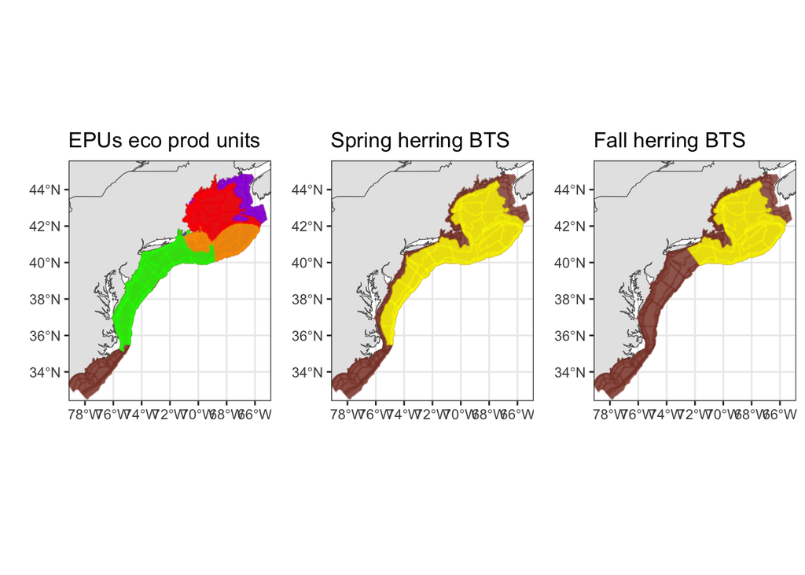

```r
theme_set(theme_bw())

herring_spring <- c(01010, 01020, 01030, 01040, 01050, 01060, 01070, 01080, 01090,
                    01100, 01110, 01120, 01130, 01140, 01150, 01160, 01170, 01180,
                    01190, 01200, 01210, 01220, 01230, 01240, 01250, 01260, 01270,
                    01280, 01290, 01300, 01360, 01370, 01380, 01390, 01400, 01610,
                    01620, 01630, 01640, 01650, 01660, 01670, 01680, 01690, 01700,
                    01710, 01720, 01730, 01740, 01750, 01760)
herring_fall <- c(01050, 01060, 01070, 01080, 01090, 01100, 01110, 01120, 01130,
                  01140, 01150, 01160, 01170, 01180, 01190, 01200, 01210, 01220,
                  01230, 01240, 01250, 01260, 01270, 01280, 01290, 01300, 01360,
                  01370, 01380, 01390, 01400)

herring_springgrid <-  FishStatsUtils::northwest_atlantic_grid %>%
  filter(stratum_number %in% herring_spring)

herring_fallgrid <-  FishStatsUtils::northwest_atlantic_grid %>%
  filter(stratum_number %in% herring_fall)

MAB <- c(1010:1080, 1100:1120, 1600:1750, 3010:3450, 3470, 3500, 3510)
GB  <- c(1090, 1130:1210, 1230, 1250, 3460, 3480, 3490, 3520:3550)
GOM <- c(1220, 1240, 1260:1290, 1360:1400, 3560:3830)
SS  <- c(1300:1352, 3840:3990)

# Mid Atlantic Bight EPU
MABgrid <- FishStatsUtils::northwest_atlantic_grid %>%
  dplyr::filter(stratum_number %in% MAB)

# Georges Bank EPU
GBgrid <- FishStatsUtils::northwest_atlantic_grid %>%
  dplyr::filter(stratum_number %in% GB)

# gulf of maine EPU (for SOE)
GOMgrid <- FishStatsUtils::northwest_atlantic_grid %>%
  dplyr::filter(stratum_number %in% GOM)

# scotian shelf EPU (for SOE)
SSgrid <- FishStatsUtils::northwest_atlantic_grid %>%
  dplyr::filter(stratum_number %in% SS)


EPUs <- ggplot(data = ecodata::coast) +
  geom_sf() +
  geom_point(data = FishStatsUtils::northwest_atlantic_grid, aes(x = Lon, y = Lat),  colour = "coral4", size=0.05, alpha=0.1) +
  geom_point(data = MABgrid, aes(x = Lon, y = Lat), colour = "green", size=0.05, alpha=0.1) +
  geom_point(data = GBgrid, aes(x = Lon, y = Lat), colour = "orange", size=0.05, alpha=0.1) +
  geom_point(data = GOMgrid, aes(x = Lon, y = Lat), colour = "red", size=0.05, alpha=0.1) +
  geom_point(data = SSgrid, aes(x = Lon, y = Lat), colour = "purple", size=0.05, alpha=0.1) +
  coord_sf(xlim =c(-78.5, -65.5), ylim = c(33, 45)) + #zoomed to Hatteras and N
  xlab("") +
  ylab("") +
  ggtitle("EPUs eco prod units")+
  theme(plot.margin = margin(0, 0, 0, 0, "cm"))

Fall <- ggplot(data = ecodata::coast) +
  geom_sf() +
  geom_point(data = FishStatsUtils::northwest_atlantic_grid, aes(x = Lon, y = Lat),  colour = "coral4", size=0.05, alpha=0.1) +
  geom_point(data = herring_fallgrid, aes(x = Lon, y = Lat),  colour = "yellow", size=0.05, alpha=0.1) +
  coord_sf(xlim =c(-78.5, -65.5), ylim = c(33, 45)) + #zoomed to Hatteras and N
  xlab("") +
  ylab("") +
  ggtitle("Fall herring BTS")+
  theme(plot.margin = margin(0, 0, 0, 0, "cm"))

Spring <- ggplot(data = ecodata::coast) +
  geom_sf() +
  geom_point(data = FishStatsUtils::northwest_atlantic_grid, aes(x = Lon, y = Lat),  colour = "coral4", size=0.05, alpha=0.1) +
  geom_point(data = herring_springgrid, aes(x = Lon, y = Lat),  colour = "yellow", size=0.05, alpha=0.1) +
  coord_sf(xlim =c(-78.5, -65.5), ylim = c(33, 45)) + #zoomed to Hatteras and N
  xlab("") +
  ylab("") +
  ggtitle("Spring herring BTS")+
  theme(plot.margin = margin(0, 0, 0, 0, "cm"))

EPUs + Spring + Fall
```

## Indices by group, season, and region

```r
stratlook <- data.frame(Stratum = c("Stratum_1",
                                    "Stratum_2",
                                    "Stratum_3",
                                    "Stratum_4",
                                    "Stratum_5",
                                    "Stratum_6",
                                    "Stratum_7"),
                        Region  = c("AllEPU",
                                    "her_sp",
                                    "her_fa",
                                    "MAB",
                                    "GB",
                                    "GOM",
                                    "SS"))

# function to apply extracting info
getmodindex <- function(d.name){
  # read settings
  modpath <- stringr::str_split(d.name, "/", simplify = TRUE)
  modname <- modpath[length(modpath)]

  if(file.exists(file.path(d.name,"Index.csv"))){
    index <- read.csv(file.path(d.name, "Index.csv"))
  }else{
    stopifnot()
  }
  # return model indices as a dataframe
  out <- data.frame(modname = modname,
                    index
  )

  return(out)
}

modcompareindex <- purrr::map_dfr(moddirs, purrr::possibly(getmodindex, otherwise = NULL))

splitoutput <- modcompareindex %>%
  dplyr::mutate(Season = modname |> map(str_split, pattern = "_") |> map_chr(c(1,2))) %>%
  dplyr::mutate(Data = modname |> map(str_split, pattern = "_") |> map_chr(c(1,1))) %>%
  dplyr::mutate(Estimate = ifelse(Estimate == 0, NA, Estimate)) |>
  dplyr::left_join(stratlook) #%>%
  #dplyr::filter(Region %in% c(GOM", "GB", "MAB","SS", "AllEPU")) use all regions

zoomax <- max(splitoutput$Estimate, na.rm=T)


zootsmean <- splitoutput %>%
  dplyr::group_by(modname, Region) %>%
  dplyr::mutate(fmean = mean(Estimate, na.rm=T))
```

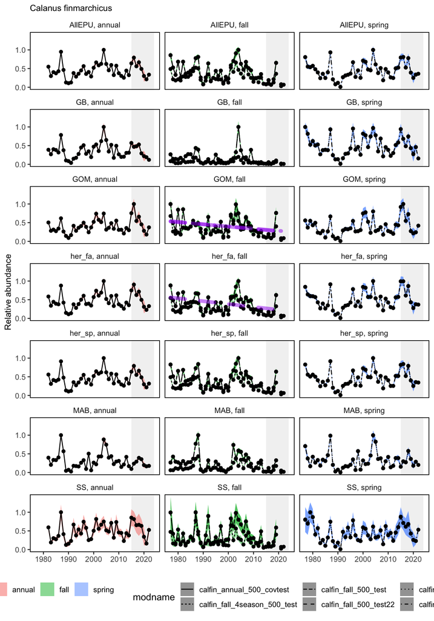

```r
plot_zooindices <- function(splitoutput, plotdata, plotregions, plottitle){

  filterEPUs <- plotregions #c("her_sp", "her_fa", "MAB", "GB", "GOM", "SS", "AllEPU")

  seasons <- splitoutput |> dplyr::filter(Data==plotdata) |> dplyr::select(Season) |> dplyr::distinct()

  ncols <- dim(seasons)[1]

  currentMonth <- lubridate::month(Sys.Date())
  currentYear <- lubridate::year(Sys.Date())
  if (currentMonth > 4) {
    endShade <- currentYear
  } else {
    endShade <- currentYear - 1
  }
  shadedRegion <- c(endShade-9,endShade)

  shade.alpha <- 0.3
  shade.fill <- "lightgrey"
  lwd <- 1
  pcex <- 2
  trend.alpha <- 0.5
  trend.size <- 2
  hline.size <- 1
  line.size <- 2
  hline.alpha <- 0.35
  hline.lty <- "dashed"
  label.size <- 5
  hjust.label <- 1.5
  letter_size <- 4
  errorbar.width <- 0.25
  x.shade.min <- shadedRegion[1]
  x.shade.max <- shadedRegion[2]

  setup <- list(
    shade.alpha = shade.alpha,
    shade.fill =shade.fill,
    lwd = lwd,
    pcex = pcex,
    trend.alpha = trend.alpha,
    trend.size = trend.size,
    line.size = line.size,
    hline.size = hline.size,
    hline.alpha = hline.alpha,
    hline.lty = hline.lty,
    errorbar.width = errorbar.width,
    label.size = label.size,
    hjust.label = hjust.label,
    letter_size = letter_size,
    x.shade.min = x.shade.min,
    x.shade.max = x.shade.max
  )


  fix<- splitoutput |>
    dplyr::filter(Data %in% plotdata, #c("calfin"),
                  Region %in% filterEPUs) |>
    dplyr::group_by(Region, Season) |>
    dplyr::summarise(max = max(Estimate, na.rm=T))

  p <- splitoutput |>
    dplyr::filter(Data %in% plotdata, #c("calfin"),
                  Region %in% filterEPUs) |>
    dplyr::group_by(Region, Season) |>
    dplyr::left_join(fix) |>
    dplyr::mutate(#Value = Value/resca,
      Mean = as.numeric(Estimate),
      SE = Std..Error.for.Estimate,
      Mean = Mean/max,
      SE = SE/max,
      Upper = Mean + SE,
      Lower = Mean - SE) |>
    ggplot2::ggplot(ggplot2::aes(x = Time, y = Mean, linetype = modname, group = modname))+
    ggplot2::annotate("rect", fill = setup$shade.fill, alpha = setup$shade.alpha,
                      xmin = setup$x.shade.min , xmax = setup$x.shade.max,
                      ymin = -Inf, ymax = Inf) +
    ggplot2::geom_ribbon(ggplot2::aes(ymin = Lower, ymax = Upper, fill = Season), alpha = 0.5)+
    ggplot2::geom_point()+
    ggplot2::geom_line()+
    ggplot2::ggtitle(plottitle)+
    ggplot2::ylab(expression("Relative abundance"))+
    ggplot2::xlab(ggplot2::element_blank())+
    ggplot2::facet_wrap(Region~Season, ncol = ncols,
                        labeller = label_wrap_gen(multi_line=FALSE))+
    ecodata::geom_gls()+
    ecodata::theme_ts()+
    ecodata::theme_facet()+
    ecodata::theme_title() +
    ggplot2::theme(legend.position = "bottom")

  return(p)
}


plot_zooindices(splitoutput = splitoutput,
             plotdata = "calfin",
             plotregions = c("her_sp", "her_fa", "MAB", "GB", "GOM", "SS", "AllEPU"),
             plottitle = "Calanus finmarchicus")
```

Compare calfin annual VAST (blue) with SOE annual anomalies (black)

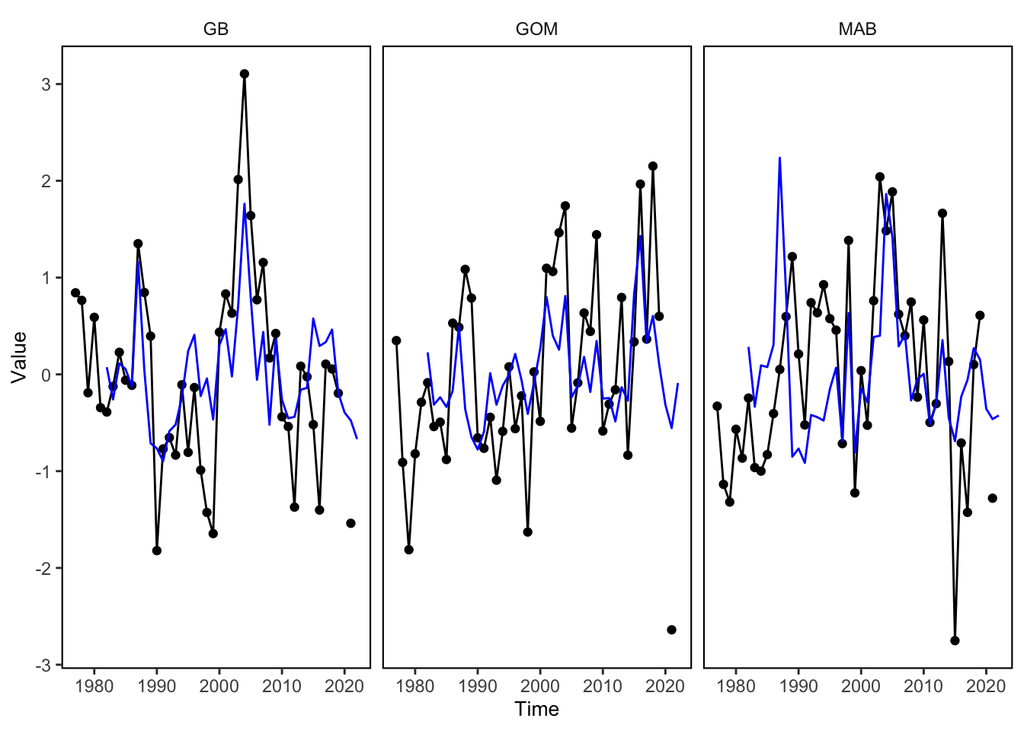

```r
VASTmean <- splitoutput |>
    dplyr::filter(Data %in% c("calfin"),
                  Season %in% c("annual"),
                  Region %in% c("MAB", "GB", "GOM")) |>
    dplyr::group_by(Region, Season) |>
    dplyr::summarise(tsmean = mean(Estimate))

VASTanom <- splitoutput |>
    dplyr::filter(Data %in% c("calfin"),
                  Season %in% c("annual"),
                  Region %in% c("MAB", "GB", "GOM")) |>
    dplyr::left_join(VASTmean) |>
    dplyr::group_by(Region, Season) |>
    dplyr::mutate(#Value = Value/resca,
      Mean = as.numeric(Estimate),
      SE = Std..Error.for.Estimate,
      Mean = (Mean-tsmean)/tsmean,
      SE = (SE-tsmean)/tsmean,
      Upper = Mean + SE,
      Lower = Mean - SE) |>
  dplyr::rename(EPU = Region)

SOEcalfin <- ecodata::zoo_abundance_anom |>
  dplyr::mutate(Value = as.numeric(Value)) |>
  dplyr::filter(Var == "Calfin") |>
  ggplot2::ggplot(aes(x = Time, y = Value)) +
  ggplot2::geom_point() +
  ggplot2::geom_line() +
  ecodata::geom_gls() +
  ggplot2::geom_line(data = VASTanom, aes(x=Time, y=Mean), color = "blue") +
  ecodata::theme_facet() +
  ggplot2::facet_wrap(~EPU)

SOEcalfin
```

Other species

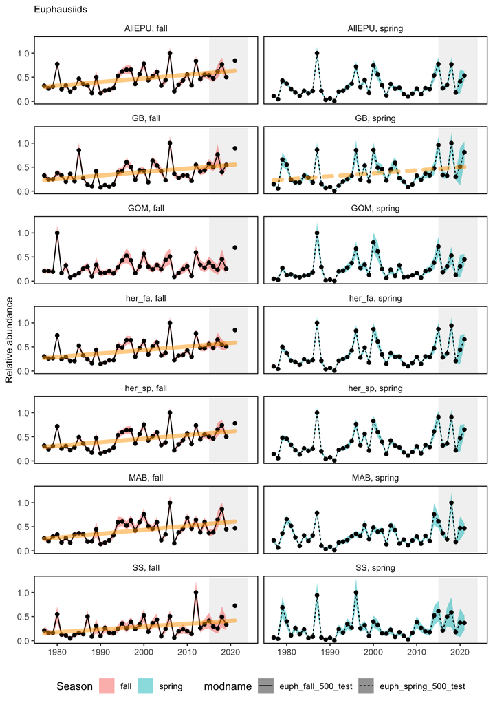

```r
plot_zooindices(splitoutput = splitoutput,
             plotdata = "euph",
             plotregions = c("her_sp", "her_fa", "MAB", "GB", "GOM", "SS", "AllEPU"),
             plottitle = "Euphausiids")
```

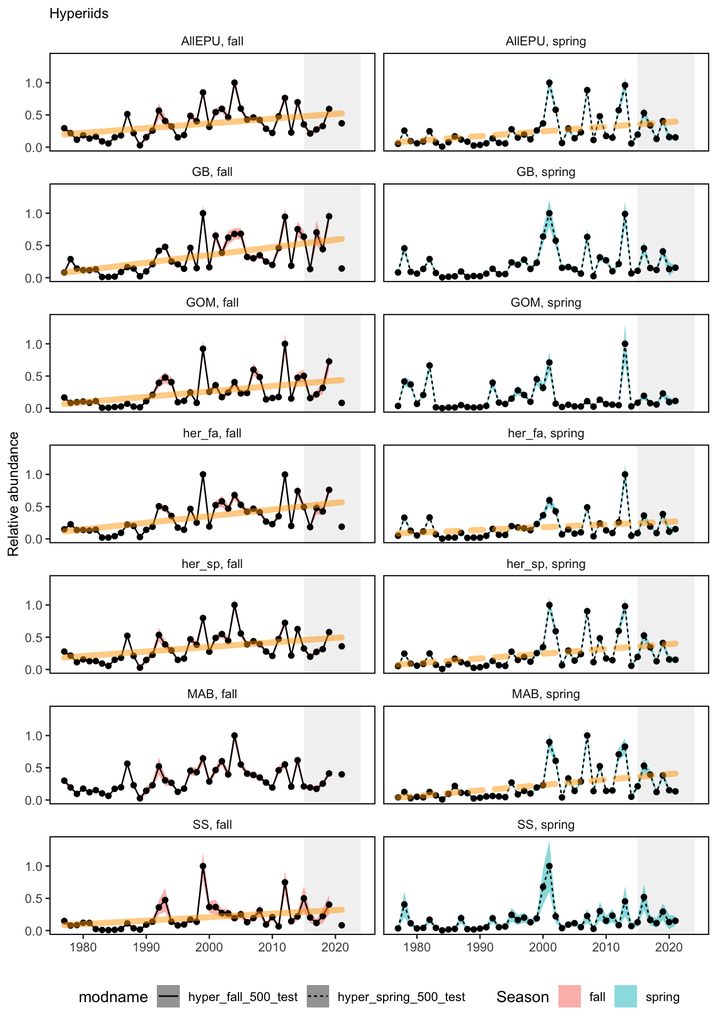

```r
plot_zooindices(splitoutput = splitoutput,
             plotdata = "hyper",
             plotregions = c("her_sp", "her_fa", "MAB", "GB", "GOM", "SS", "AllEPU"),
             plottitle = "Hyperiids")
```

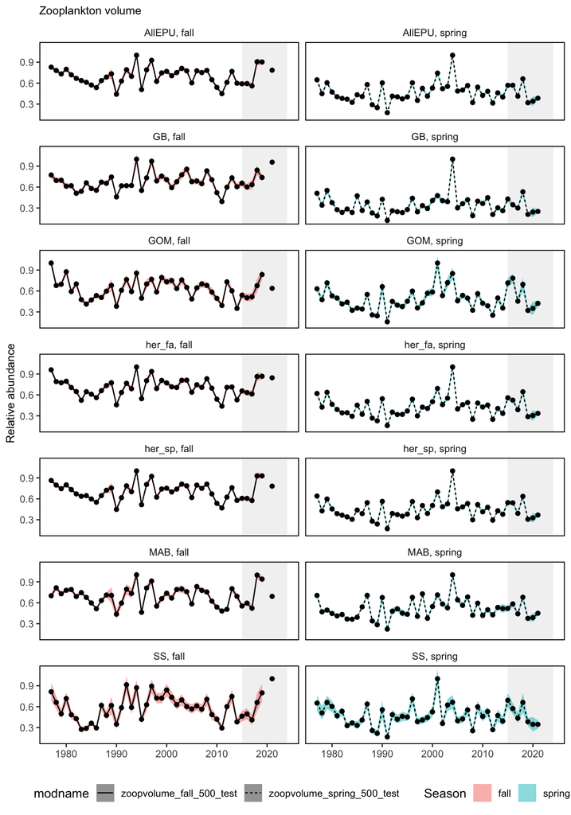

```r
plot_zooindices(splitoutput = splitoutput,
             plotdata = "zoopvolume",
             plotregions = c("her_sp", "her_fa", "MAB", "GB", "GOM", "SS", "AllEPU"),
             plottitle = "Zooplankton volume")
```